# Spiky: Analysing cfMeDIP-seq data with spike-in controls

Samantha L Wilson

15/09/2020

# Introduction

To meet the need for a reference control in cell-free methylated DNA immunoprecipitation-sequencing (cfMeDIP-seq)<sup>1,2</sup> experiments, we designed spike-in controls and ligated unique molecular indexes (UMI) to adjust for PCR bias, and immunoprecipitation bias caused by the fragment length, G+C content, and CpG density of the DNA fragments that are immunoprecipitated. This enables for absolute quantification of methylated DNA in picomoles, while retaining epigenomic information that allows for sensitive, tissue-specific detection as well as comparable results between different experiments. We designed DNA fragments with 2x3x3x3=54 combinations of methylation status (methylated and unmethylated), fragment length in basepair (bp) (80 bp, 160 bp, 320 bp), G+C content (35%, 50%, 65%), and fraction of CpGs within a fragment (1 CpG/ 80 bp, 1 CpG/ 40 bp, 1 CpG/ 20 bp). Spiky was developed for analyzing DNA methylation of cell-free DNA obtained from cfMeDIP-seq method using reference ‘spike-in’ controls. This package will:

- Assess methylation specificity in each sample
- Using the spike-in control data, output a Gaussian generalized linear model to predict molar amount on DNA samples
- Predict molar amount (picomoles) for each DNA sequence of interest, adjusting for fragment length G+C content and CpG fraction
- Adjust molar amount and bin the fragments into genomic windows used in analyses

# Installation

Install the spiky package from github.

```r
install.packages("remotes")
install.packages("BiocManager")
BiocManager::install("trichelab/spiky", build_vignettes=TRUE)

library(spiky)
```

# Methylation specificity

For each combination of parameters, we designed two distinct sequences. One to be methylated and one to be unmethylated. The allows assess to assess non-specific binding of the monoclonal antobody on a sample-by-sample basis. To calculate methylation specificity we take the number of methylated reads divided by the total number of reads. It is our reccomendation that if methylation specificity is <0.98, then the sample should be flagged or removed from analysis as the cfMeDIP performed inadequetely.

This calculation is done by the ‘calculate_methylation’ function.

### Input: spikein_data

- BAM or BED file
- Columns:
  - chrom/contig: string
  - position start: numeric
  - position end: numeric
  - read counts: integer
  - fragment length (bp): integer
  - G+C content [0-1]: numeric
  - CpG number: Integer

### Output: methylation specificity

- Number ranging 0-1 specifiy the percent of sequences that are methylated after cfMeDIP-seq has been performed

### Example

```r
## Load in deduplicated sequences aligned to the spike-in controls
spikein_data_all <- fread('2019_synfrag0.01_spikeincellline_dedup_lowconc.csv')

##Calculate methylation specificity
methylation_specificty <- calculate_methylation(spikein_data)
```

# Obtaining model that will predict the molar amount on DNA sequence of interest

For each batch of samples, the coefficients used in the Gaussian generalizaed linear model will differ. The ‘model_glm_pmol’ will calculate these coefficients and output the model to be used to calculate molar amount (picomoles) on the user’s DNA sequences of interest. We assume that all DNA sequences of interest are methylated after undergoeing cfMeDIP-seq. As such, we build the Gaussian generalized linear model on only the methylated spike-in control fragments. A generated Bland-Altman plot will visualize how well the model performs.

### Input: spikein_data

- BAM or BED file
- We remove fragments from the unmethylated sequences
- Columns:
  - chrom/contig: string
  - position start: numeric
  - position end: numeric
  - read counts: integer
  - fragment length (bp): integer
  - G+C content [0-1]: numeric
  - CpG number: Integer

### Output:

- Gaussian generalized linear model with coefficients specific to samples used in input data; .rda file
- Summary of the model; .txt file
- Bland-Altman plot; .png file

### Example

```r
## reshape the data so that 'id' is the sample
spikein_data <- load('dedup.rda')
spikein_data_melt <- melt(spikein_data, measure.vars = c('sample1','sample2'))
colnames(spikein_data_melt) <- c("frag_grp", "id", "read")

## Build the Gaussian generalized linear model on the spike-in control data
# Generate bland altman plot to visualize the model's performance on the data
gaussian_glm <- model_glm_pmol(spikein_data_melt)
summary(gaussian_glm)
```

An example of a Bland-Altman plot generated from spike-in control data.

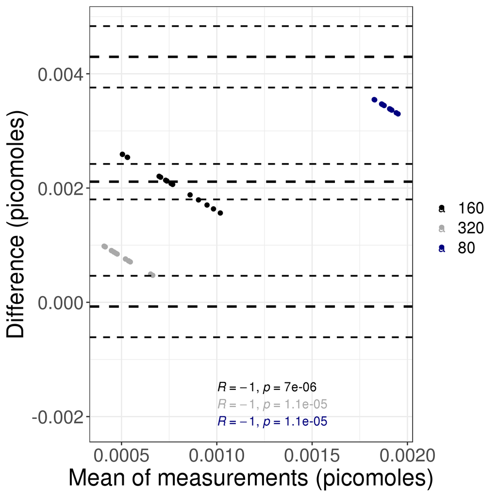

# Calculating molar amount on DNA sequences of interest

For the samples in which the Gaussian generalized linear model was built, we will calculate the molar amount (picomoles) for each DNA sequence of interest.

### Input: sample_data

- BAM or BED file; UMI deduplicated
- Columns:
  - chrom/contig: string
  - position start: numeric
  - position end: numeric
  - read counts: integer
  - fragment length (bp): integer
  - G+C content [0-1]: numeric
  - CpG number: Integer
- .rda file with the coefficients for the Gaussian generalized linear model

### Output: sample_pmol_data

- BED file
- Columns:
  - chrom: string
  - position start: numeric
  - position end: numeric
  - read counts: integer
  - fragment length (bp): integer
  - G+C content [0-1]: numeric
  - CpG number: integer
  - pmol: numeric

### Example

```r
## Load in deduplicated sequences aligned to the human reference geome
sample_data <- load("testGR.rda")
sample_data <- as.data.frame(sample_data)
sample_data$read_count <- sample_data$score
sample_data$fraglen <- sample_data$width

## Calculate molar amount (picomoles)
sample_data_pmol <- predict_pmol(gaussian_glm, sample_data)
```

# Adjusting molar amount to binned genomic windows

For our analyses, we binned the genome into 300 bp non-overlapping windows. We then look overlap between fragments in our data with each of the 300 bp genomic windows. We adjust the molar amount (picomoles) by a multipier. This multipier is the proportion of overlap between our fragment and the 300 bp window. This is done for every fragment in our sample.

### Input: sample_pmol_data

- BED file from the ‘predict_pmol’ function
- Columns: * chrom: string * position start: numeric * position end: numeric * read counts: integer * fragment length (bp): integer * G+C content [0-1]: numeric * CpG number: integer * pmol: numeric

### Output: sample_binned_data

- BED file
- Columns: * chrom: string * position start: numeric * position end: numeric * fragment length (bp): integer * G+C content [0-1]: numeric * CpG number: integer * pmol: numeric

### Example

```r
sample_binned_data <- bin_pmol(sample_pmol_data)
```

# References

1. Shen, S. Y. *et al.* Sensitive tumour detection and classification using plasma cell-free dna methylomes. *Nature* **563**, 579–583 (2018).

2. Shen, S. Y., Burgener, J. M., Bratman, S. V. & De Carvalho, D. D. Preparation of cfMeDIP-seq libraries for methylome profiling of plasma cell-free dna. *Nature protocols* **14**, 2749–2780 (2019).